# Vorhersage-Modellierung des Diamantenpreises

ses

7/6/2021

# 1 Vorbereitung

## 1.1 Forschungsfrage

*Welche Prädiktoren lassen den Preis einen Diamanten vorhersagen?*

Wir möchten also den Preis von Diamanten - basierend auf einer Reihe von Prädiktoren - möglichst exakt vorhersagen ($R^2$).

## 1.2 Aufgabe für Gruppenarbeit

Berechnen Sie die Vorhersagen und auch das R-Quadrat im Test-Datensatz!

Zeit bis 16.00h. Wir treffen uns um 16h im Plenum.

## 1.3 Pakete laden

```r
library(tidyverse)
library(fastDummies)
library(janitor)
library(corrr)
library(ggfortify)
library(modelr)
library(tidymodels)
library(leaps)
```

## 1.4 Daten laden

```r
train <- read_csv("https://raw.githubusercontent.com/sebastiansauer/2021-sose/master/data/diamonds/diamonds_train.csv")
test <- read_csv("https://raw.githubusercontent.com/sebastiansauer/2021-sose/master/data/diamonds/diamonds_test.csv")
solution <- read_csv("https://raw.githubusercontent.com/sebastiansauer/2021-sose/master/data/diamonds/diamonds_solution.csv")
```

## 1.5 ID-Spalte ergänzen

```r
test <-
  test %>%
  mutate(id = 1:nrow(.))
```

```r
solution <-
  solution %>%
  mutate(id = 1:nrow(.))
```

# 2 Einzelne Werte in einer Tabelle (Dataframe) ändern

(Nur zur Anschauung, nicht Teil der Fallstudie)

```r
train$carat[1] <- NA
```

# 3 Vorwissen

Etwas Recherche oder Vorwissen zeigt, dass beim Diamantenpreis die “4C” entscheidend sind: Color, Clarity, **Carat**, Cut.

Entsprechend sind diese 4 Prädiktoren gute Kandidaten für ein Modell.

Tipp: Haben zwei Prädiktoren jeweils einen starken *Haupteffekt* (der Effekt einer einzelnen Variablen im Gegensatz zu einem Interaktionseffekt), macht es *häufig* Sinn, ihre Interaktion mitaufzunehmen (s. Gelman und Hill, 2007, Kap. 3 oder 4). Der Umkehrschluss gilt nicht.

# 4 Woran erkennt man einen “starken Haupteffekt”?

1. Am Zuwachs von $R^2$, wenn man den Prädiktor mitaufnimmt
2. Am Regressiongewicht – aber nur, wenn die Prädiktoren (z-)standardisiert sind.

# 5 Wichtige Prädiktoren

## 5.1 train2

```r
train2 <- train %>%
  dummy_cols(remove_selected_columns = TRUE,
             select_columns = c("cut", "color", "clarity"),
             remove_first_dummy = TRUE) %>%
  clean_names()
```

```r
train2 %>% glimpse()
```

```
## Rows: 40,453
## Columns: 24
## $ carat         <dbl> NA, 0.31, 0.24, 0.26, 0.22, 0.23, 0.30, 0.23, 0.22, 0.20…
## $ depth         <dbl> 61.5, 63.3, 62.8, 61.9, 65.1, 59.4, 64.0, 62.8, 60.4, 60…
## $ table         <dbl> 55, 58, 57, 55, 61, 61, 55, 56, 61, 62, 58, 54, 54, 56, …
## $ price         <dbl> 326, 335, 336, 337, 337, 338, 339, 340, 342, 345, 345, 3…
## $ x             <dbl> 3.95, 4.34, 3.94, 4.07, 3.87, 4.00, 4.25, 3.93, 3.88, 3.…
## $ y             <dbl> 3.98, 4.35, 3.96, 4.11, 3.78, 4.05, 4.28, 3.90, 3.84, 3.…
## $ z             <dbl> 2.43, 2.75, 2.48, 2.53, 2.49, 2.39, 2.73, 2.46, 2.33, 2.…
## $ cut_good      <int> 0, 1, 0, 0, 0, 0, 1, 0, 0, 0, 0, 0, 1, 1, 0, 1, 0, 0, 0,…
## $ cut_ideal     <int> 1, 0, 0, 0, 0, 0, 0, 1, 0, 0, 0, 1, 0, 0, 0, 0, 0, 0, 0,…
## $ cut_premium   <int> 0, 0, 0, 0, 0, 0, 0, 0, 1, 1, 1, 0, 0, 0, 0, 0, 0, 0, 0,…
## $ cut_very_good <int> 0, 0, 1, 1, 0, 1, 0, 0, 0, 0, 0, 0, 0, 0, 1, 0, 1, 1, 1,…
## $ color_e       <int> 1, 0, 0, 0, 1, 0, 0, 0, 0, 1, 1, 0, 0, 0, 0, 0, 1, 0, 0,…
## $ color_f       <int> 0, 0, 0, 0, 0, 0, 0, 0, 1, 0, 0, 0, 0, 0, 0, 0, 0, 0, 0,…
## $ color_g       <int> 0, 0, 0, 0, 0, 0, 0, 0, 0, 0, 0, 0, 0, 0, 0, 0, 0, 0, 0,…
## $ color_h       <int> 0, 0, 0, 1, 0, 1, 0, 0, 0, 0, 0, 0, 0, 0, 0, 0, 0, 1, 0,…
## $ color_i       <int> 0, 0, 0, 0, 0, 0, 0, 0, 0, 0, 0, 1, 0, 0, 0, 1, 0, 0, 0,…
## $ color_j       <int> 0, 1, 1, 0, 0, 0, 1, 1, 0, 0, 0, 0, 1, 1, 1, 0, 0, 0, 1,…
## $ clarity_if    <int> 0, 0, 0, 0, 0, 0, 0, 0, 0, 0, 0, 0, 0, 0, 0, 0, 0, 0, 0,…
## $ clarity_si1   <int> 0, 0, 0, 1, 0, 0, 1, 0, 1, 0, 0, 0, 1, 1, 1, 0, 0, 0, 1,…
## $ clarity_si2   <int> 1, 1, 0, 0, 0, 0, 0, 0, 0, 1, 0, 1, 0, 0, 0, 1, 0, 0, 0,…
## $ clarity_vs1   <int> 0, 0, 0, 0, 0, 1, 0, 1, 0, 0, 0, 0, 0, 0, 0, 0, 0, 1, 0,…
## $ clarity_vs2   <int> 0, 0, 0, 0, 1, 0, 0, 0, 0, 0, 0, 0, 0, 0, 0, 0, 1, 0, 0,…
## $ clarity_vvs1  <int> 0, 0, 0, 0, 0, 0, 0, 0, 0, 0, 0, 0, 0, 0, 0, 0, 0, 0, 0,…
## $ clarity_vvs2  <int> 0, 0, 1, 0, 0, 0, 0, 0, 0, 0, 0, 0, 0, 0, 0, 0, 0, 0, 0,…
```

## 5.2 test2

```r
test2 <- test %>%
  dummy_cols(remove_selected_columns = TRUE,
             select_columns = c("cut", "color", "clarity")) %>%
  clean_names()
```

```r
train2 %>%
  correlate() %>%
  focus(price) %>%
  arrange(-abs(price)) %>%
  filter(abs(price) > 0.1)
```

```
##
## Correlation method: 'pearson'
## Missing treated using: 'pairwise.complete.obs'
```

```
## # A tibble: 7 x 2
##   term         price
##   <chr>        <dbl>
## 1 carat        0.922
## 2 x            0.886
## 3 y            0.860
## 4 z            0.858
## 5 clarity_si2  0.128
## 6 table        0.128
## 7 color_e     -0.103
```

# 6 Feature Engineering

```r
train2 %>%
  mutate(volume = x*y*z) %>%
  correlate() %>%
  focus(volume)
```

```
##
## Correlation method: 'pearson'
## Missing treated using: 'pairwise.complete.obs'
```

```
## # A tibble: 24 x 2
##    term          volume
##    <chr>          <dbl>
##  1 carat        0.970
##  2 depth        0.00576
##  3 table        0.168
##  4 price        0.897
##  5 x            0.950
##  6 y            0.975
##  7 z            0.942
##  8 cut_good     0.0257
##  9 cut_ideal   -0.150
## 10 cut_premium  0.114
## # … with 14 more rows
```

## 6.1 train3/test3

```r
train3 <-
  train2 %>%
  mutate(volume = x*y*z)
```

```r
test3 <-
  test2 %>%
  mutate(volume = x*y*z)
```

## 6.2 Korrelation

```r
train3 %>%
  correlate() %>%
  focus(price) %>%
  arrange(-abs(price)) %>%
  filter(abs(price) > 0.1)
```

```
##
## Correlation method: 'pearson'
## Missing treated using: 'pairwise.complete.obs'
```

```
## # A tibble: 8 x 2
##   term         price
##   <chr>        <dbl>
## 1 carat        0.922
## 2 volume       0.897
## 3 x            0.886
## 4 y            0.860
## 5 z            0.858
## 6 clarity_si2  0.128
## 7 table        0.128
## 8 color_e     -0.103
```

## 6.3 `preds_important`

```r
preds_important <-
  train3 %>%
  correlate() %>%
  focus(price) %>%
  arrange(-abs(price)) %>%
  filter(abs(price) > 0.1) %>%
  filter(!(term %in% c("x", "y", "z"))) %>%
  pull(term)
```

```
##
## Correlation method: 'pearson'
## Missing treated using: 'pairwise.complete.obs'
```

```r
preds_important
```

```
## [1] "carat"       "volume"      "clarity_si2" "table"       "color_e"
```

# 7 Funktionale Form der Zusammenhänge

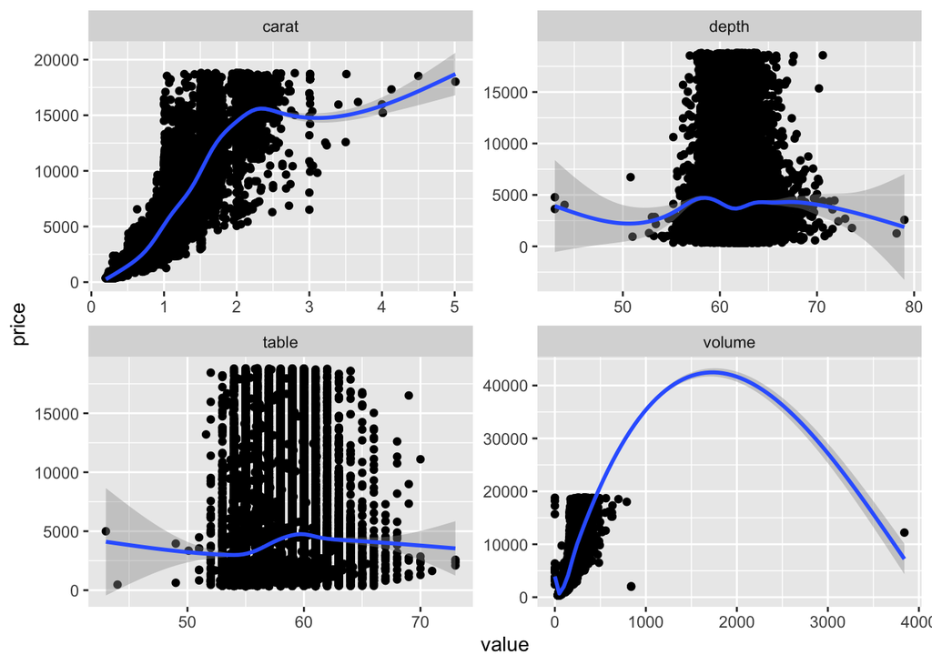

```r
train3 %>%
  select(carat, depth, table, price, volume) %>%
  pivot_longer(cols = -price) %>%
  ggplot() +
  aes(x = value, y = price) +
  geom_point() +
  geom_smooth() +
  facet_wrap(~ name, scales = "free")
```

# 8 Filtern

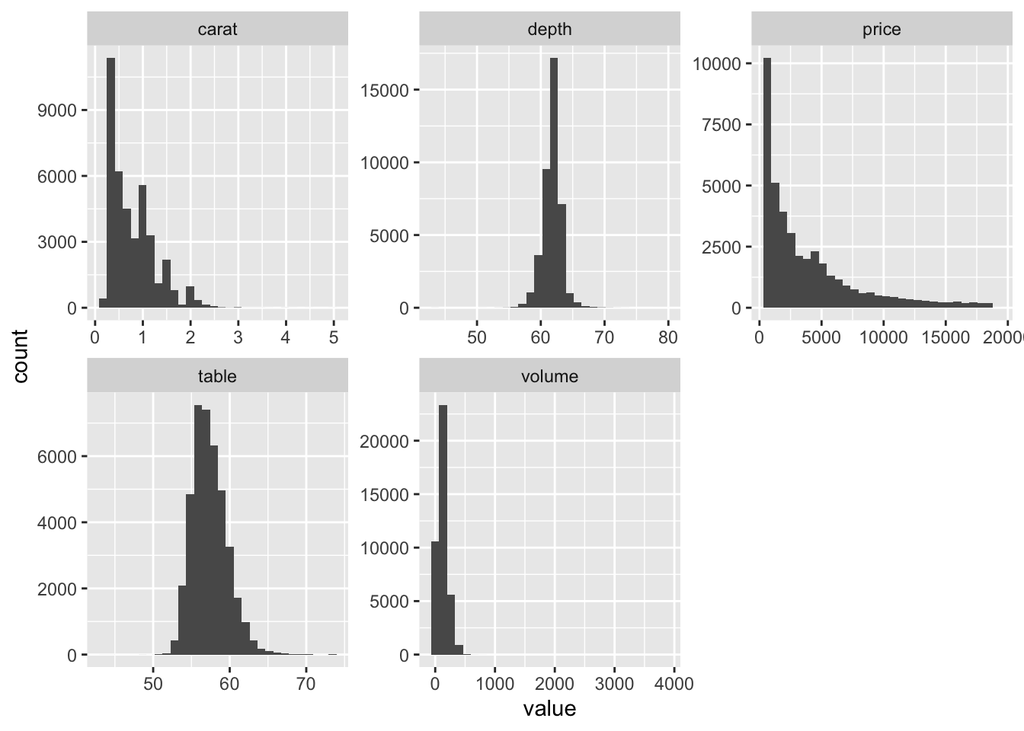

```r
train3 %>%
  select(carat, depth, table, price, volume) %>%
  pivot_longer(cols = everything()) %>%
  ggplot() +
  aes(x = value) +
  geom_histogram() +
  facet_wrap(~ name, scales = "free")
```

## 8.1 train4

```r
train4 <-
  train3 %>%
  filter(carat < 2.5)
```

# 9 z-Transformation

```r
train5 <-
  train4 %>%
  mutate(across(
    .cols = c(carat:z, volume),
    .fns = ~ (.x - mean(.x)) / sd(.x)
  ))
```

# 10 Vorhersage-Modellierung

## 10.1 lm1

```r
lm1 <-
  train5 %>%
  select(any_of(preds_important), price) %>%
  filter(price > 0) %>%
  lm(log(price) ~ . , data = .)
```

```r
summary(lm1)$adj.r.squared
```

```
## [1] 0.567623
```

```r
coef(lm1)
```

```
## (Intercept)       carat      volume clarity_si2       table     color_e
## -1.67805279  1.21459462  0.03813599 -0.88697114 -0.10408561  0.26871689
```

## 10.2 lm2

```r
lm2 <-
  train4 %>%
  select(any_of(preds_important), price) %>%
  lm(log(price) ~ log(carat) + clarity_si2 + table + color_e, data = .)
```

```r
summary(lm2)$adj.r.sq
```

```
## [1] 0.9448386
```

```r
coef(lm2)
```

```
## (Intercept)  log(carat) clarity_si2       table     color_e
##  9.17691507  1.74672794 -0.27351777 -0.01166320  0.09842534
```

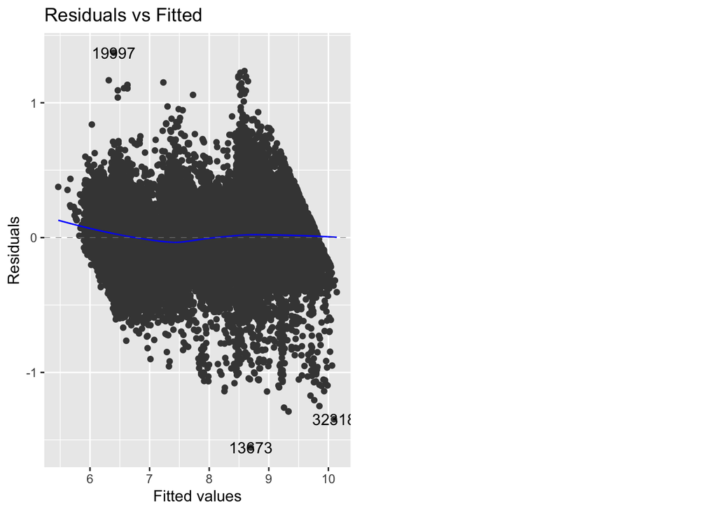

```r
autoplot(lm2, which = 1)  # ggfortify
```

## 10.3 lm3

```r
lm3 <-
  train4 %>%
  select(any_of(preds_important), price) %>%
  lm(log(price) ~ log(carat) + clarity_si2 + color_e + log(carat)*clarity_si2 + clarity_si2*color_e, data = .)
```

```r
summary(lm3)$adj.r.sq
```

```
## [1] 0.944468
```

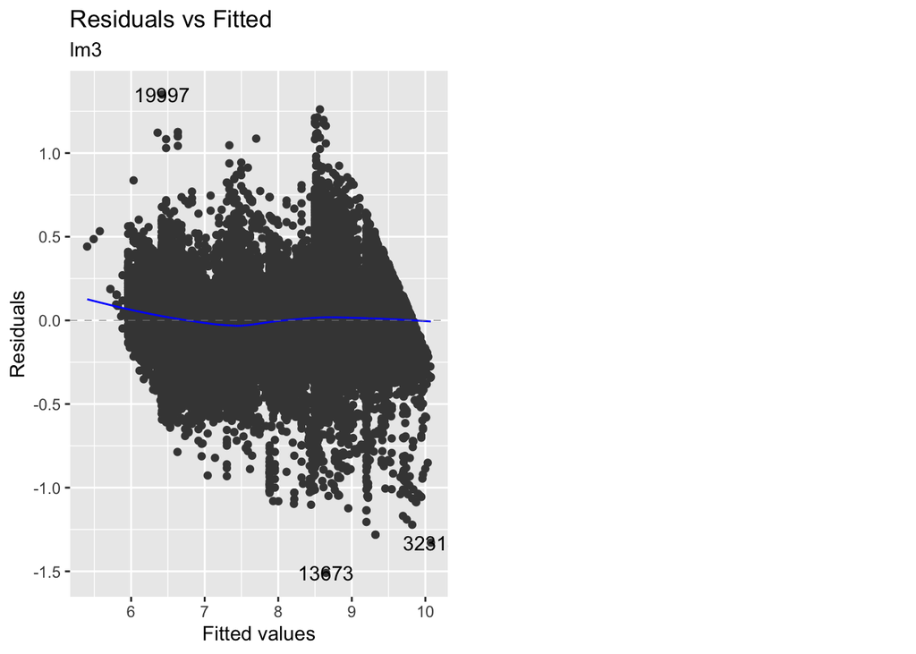

```r
autoplot(lm3, which = 1) + # ggfortify
  labs(subtitle = "lm3")
```

## 10.4 lm4

```r
lm4 <-
  train4 %>%
  select(any_of(preds_important), price) %>%
  lm(log(price) ~ log(carat) + clarity_si2 + color_e,
     data = .)
```

```r
summary(lm4)$adj.r.sq
```

```
## [1] 0.9442114
```

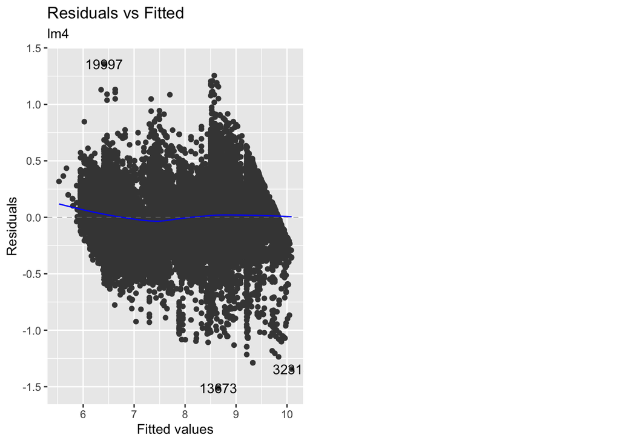

```r
autoplot(lm4, which = 1) + # ggfortify
  labs(subtitle = "lm4")
```

## 10.5 lm5

```r
lm5 <-
  train4 %>%
  select(any_of(preds_important), price) %>%
  lm(price ~ .,
     data = .)
```

```r
summary(lm5)$adj.r.sq
```

```
## [1] 0.8715257
```

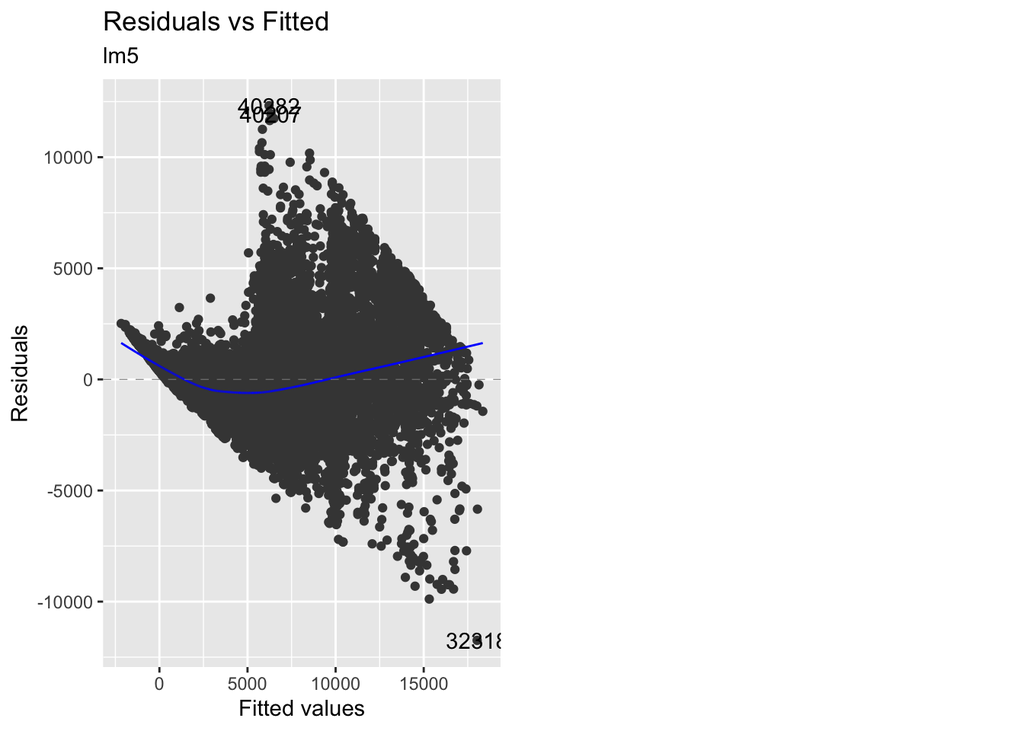

```r
autoplot(lm5, which = 1) + # ggfortify
  labs(subtitle = "lm5")
```

## 10.6 lm6

```r
lm6 <-
  train4 %>%
  lm(price ~ .,
     data = .)
```

```r
summary(lm6)$adj.r.sq
```

```
## [1] 0.9267735
```

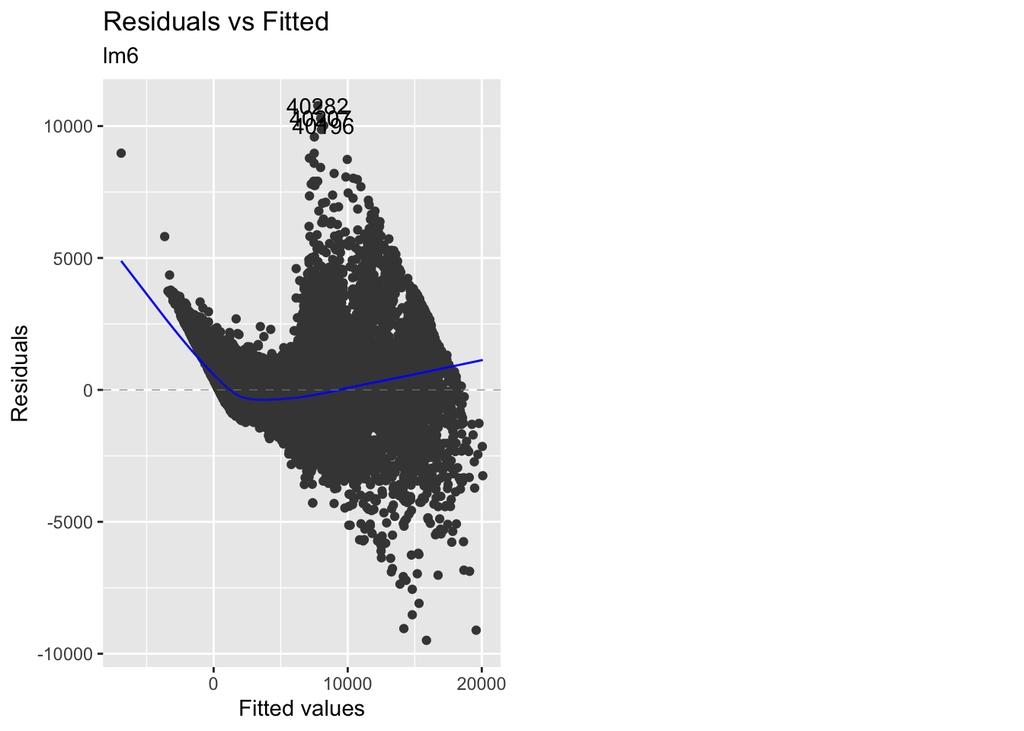

```r
autoplot(lm6, which = 1) + # ggfortify
  labs(subtitle = "lm6")
```

## 10.7 lm7: regsubsets

```r
lm7 <- regsubsets(price ~ .,
                  nvmax = 20,
                  data = train3)
```

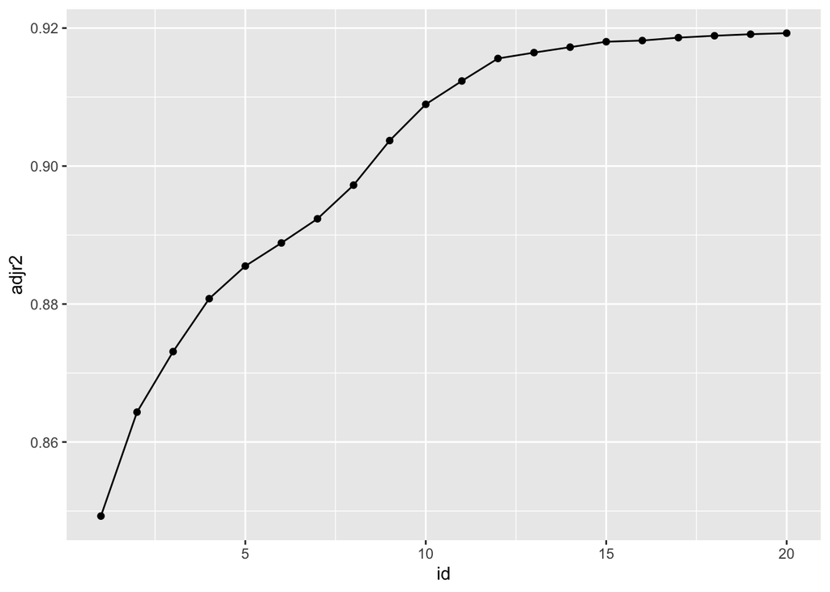

```r
lm7_sum <- summary(lm7)

tibble(adjr2 = lm7_sum$adjr2,
       id = 1:20) %>%
  ggplot() +
  aes(x = id, y = adjr2) +
  geom_point() +
  geom_line()
```

```r
coef(lm7, 12) %>% names()
```

```
##  [1] "(Intercept)"  "carat"        "x"            "color_h"      "color_i"
##  [6] "color_j"      "clarity_if"   "clarity_si1"  "clarity_si2"  "clarity_vs1"
## [11] "clarity_vs2"  "clarity_vvs1" "clarity_vvs2"
```

Dieses Modell könnte sinnvoll sein: hohes R-Quadrat, aber noch vor der “Abflachung”.

## 10.8 lm8: Schrittweise Regression

```r
lm8 <- regsubsets(price ~ .,
                  method = "forward",
                  data = train3)
```

# 11 Predict

```r
test3 <-
  test3 %>%
  add_predictions(lm1, var = "pred_lm1") %>%
  add_predictions(lm2, var = "pred_log_lm2") %>%
  add_predictions(lm3, var = "pred_log_lm3") %>%
  add_predictions(lm4, var = "pred_log_lm4") %>%
  add_predictions(lm5, var = "pred_lm5")  %>%
  add_predictions(lm6, var = "pred_lm6")
```

```r
test3 %>%
  select(contains("pred")) %>%
  slice(1:5)
```

```
## # A tibble: 5 x 6
##   pred_lm1 pred_log_lm2 pred_log_lm3 pred_log_lm4 pred_lm5 pred_lm6
##      <dbl>        <dbl>        <dbl>        <dbl>    <dbl>    <dbl>
## 1    -6.19         5.84         5.90         5.89    -624.    -394.
## 2    -6.44         5.95         6.06         6.05    -737.     420.
## 3    -5.58         6.34         6.36         6.35    -133.    -778.
## 4    -5.84         6.02         6.03         6.02    -477.    -237.
## 5    -5.84         6.23         6.11         6.19   -1079.   -2994.
```

## 11.1 Zurücktransformieren

Delogarithmieren, d.h. die Exp.funktion anwenden:

```r
test3 <-
  test3 %>%
  mutate(pred_lm2 = exp(pred_log_lm2),
         pred_lm3 = exp(pred_log_lm3),
         pred_lm4 = exp(pred_log_lm4))
```

```r
test3 %>%
  select(contains("pred")) %>%
  slice(1:5)
```

```
## # A tibble: 5 x 9
##   pred_lm1 pred_log_lm2 pred_log_lm3 pred_log_lm4 pred_lm5 pred_lm6 pred_lm2
##      <dbl>        <dbl>        <dbl>        <dbl>    <dbl>    <dbl>    <dbl>
## 1    -6.19         5.84         5.90         5.89    -624.    -394.     343.
## 2    -6.44         5.95         6.06         6.05    -737.     420.     384.
## 3    -5.58         6.34         6.36         6.35    -133.    -778.     566.
## 4    -5.84         6.02         6.03         6.02    -477.    -237.     411.
## 5    -5.84         6.23         6.11         6.19   -1079.   -2994.     507.
## # … with 2 more variables: pred_lm3 <dbl>, pred_lm4 <dbl>
```

# 12 Test-R2

```r
solutions2 <-
  solution %>% select(id, price)

test3 %>%
  select(id, contains("pred")) %>%
  left_join(solutions2) %>%
  summarise(r2_lm1 = rsq_vec(price, pred_lm1),
            r2_lm2 = rsq_vec(price, pred_lm2),
            r2_lm3 = rsq_vec(price, pred_lm3),
            r2_lm4 = rsq_vec(price, pred_lm4),
            r2_lm5 = rsq_vec(price, pred_lm5),
            r2_lm6 = rsq_vec(price, pred_lm6)) %>%
  pivot_longer(everything())
```

```
## # A tibble: 6 x 2
##   name   value
##   <chr>  <dbl>
## 1 r2_lm1 0.863
## 2 r2_lm2 0.856
## 3 r2_lm3 0.857
## 4 r2_lm4 0.856
## 5 r2_lm5 0.866
## 6 r2_lm6 0.920
```